# Untitled

celiaflorea

1/31/2021

```r
library(papaja)

apa6_pdf(fig_caption = TRUE,
  number_sections = FALSE,
  toc = FALSE,
  keep_tex = TRUE,
  md_extensions = NULL,
  implicit_figures=TRUE)
```

[output not shown]

[output not shown]

```r
# Seed for random number generation
set.seed(42)
knitr::opts_chunk$set(cache.extra = knitr::rand_seed)
```

This is a short example of creating an APA manuscript using papaja. It is intended to provide example code for your semester project. This would normally be the introduction to your paper. Below is a very brief introduction.

This report re-produces the analysis of Experiment 3 reported in @rosenbaum2017stand. The data were downloaded from https://osf.io/b7x8q/

@rosenbaum2017stand had participants perform a Stroop task in one of two posture conditions. Participants either sat and performed the Stroop task, or stood and performed the Stroop task. The question was whether the size of the Stroop effect would change as a function of posture. The Stroop effect is measured as a difference between reaction times on congruent vs. incongruent trials.The experiment involved a 2 (Posture: sitting vs standing) x 2 (congruency: congruent vs. incongruent) repeated measures design.

# Methods

## Participants

There were 50 participants

## Material

The details of the Stroop experiment are report in @rosenbaum2017stand

## Procedure

In each posture condition, participants completed 72 Stroop trials, half congruent and half incongruent.

# Results

```r
# Make and print the table
library(kableExtra)
library(tidyr)
# format from long to wide
wide_means <- overall_means %>%
  gather(variable, value, -(Posture:Congruency)) %>%
  unite(temp, Congruency, variable) %>%
  spread(temp, value)
# rename columns
names(wide_means)[2:5] <- c("RT","SEM","RT","SEM")
# print table
kable(wide_means, "latex", caption = "Mean Reaction Times and Standard Errors of the Mean for Experiment 3", booktabs = T) %>%
  kable_styling() %>%
  add_header_above(c(" " = 1, "Congruent" = 2, "Incongruent" = 2))
```

[output not shown]

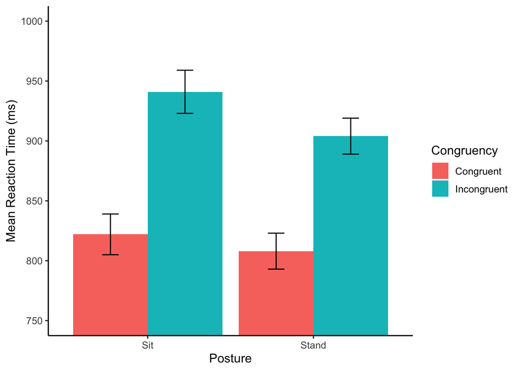

Mean reaction times wth standard error bars as a function of Posture and Congruency for Experiment 3

```r
# make and print the figure
ggplot(overall_means, aes(x=Posture,
                          y=meanRT,
                          group=Congruency,
                          fill=Congruency))+
  geom_bar(stat="identity",position="dodge")+
  theme_classic(base_size=12)+
  ylab("Mean Reaction Time (ms)")+
  geom_errorbar(aes(ymin=meanRT-SEMRT,
                    ymax=meanRT+SEMRT),
                position=position_dodge(width=0.9),
                width=.2,
                color="black")+
  coord_cartesian(ylim=c(750,1000))
```

```r
## ANOVA
# Make sure Subject is  a factor
stroop_df$Subject <-  as.factor(stroop_df$Subject)
aov_out <- aov(RTs~Posture*Congruency + Error(Subject/(Posture*Congruency)), stroop_df)
apa_aov <- apa_print(summary(aov_out))
apa_table(
  apa_aov$table
  , caption = "ANOVA table for Experiment 3"
)
```

(#tab:aovtable)

*ANOVA table for Experiment 3*

| Effect | $F$ | $\mathit{df}_1$ | $\mathit{df}_2$ | $\mathit{MSE}$ | $p$ | $\hat{\eta}^2_G$ |
| --- | --- | --- | --- | --- | --- | --- |
| Posture | 7.33 | 1 | 49 | 4,407.09 | .009 | .012 |
| Congruency | 342.45 | 1 | 49 | 1,684.39 | < .001 | .182 |
| Posture $\times$ Congruency | 8.96 | 1 | 49 | 731.82 | .004 | .003 |

Below are examples of writing the results using two methods. The first method is to report all of the values by hand. The second method is to embed the results of R variables into the reporting using papaja. Both results sections appear similar in the .pdf, so look at the .rmd file for this example to see how to use papaja.

## By hand reporting

There was a main effect of Congruency, F (1, 49) = 342.45, MSE = 1684.39, p < 0.001. Mean reaction times were slower for incongruent (922 ms) than congruent groups (815 ms).

There main effect of Posture was significant, F (1, 49) = 7.33, MSE = 4407.09, p =.009. Mean reaction times were slower for sitting (881 ms) than standing groups (855 ms).

The two-way interaction between Congruency and Posture was significant, F (1, 49) = 8.96, MSE = 731.82, p < 0.004. The Stroop effect was 23 ms smaller in the standing than sitting conditions.

## papaja reporting

There was a main effect of Congruency, $F(1, 49) = 342.45$, $\mathit{MSE} = 1,684.39$, $p < .001$, $\hat{\eta}^2_G = .182$. Mean reaction times were slower for incongruent (922 ms) than congruent groups (815 ms).

There main effect of Posture was significant, $F(1, 49) = 7.33$, $\mathit{MSE} = 4,407.09$, $p = .009$, $\hat{\eta}^2_G = .012$. Mean reaction times were slower for sitting (881 ms) than standing groups (855 ms).

The two-way interaction between Congruency and Posture was significant, $F(1, 49) = 8.96$, $\mathit{MSE} = 731.82$, $p = .004$, $\hat{\eta}^2_G = .003$. The Stroop effect was 23 ms smaller in the standing than sitting conditions.